# TP Ecologie Biodiversité Montmaur

Eric Marcon d’après Bastien Mérigot et Guillaume Papuga

2024-03-07

# Data

The classical shape of biodiversity data is a matrix where columns are species and rows are plots. Values are abundances.

## Base R version

### Read files

Load the data:

```r
zones <- read.csv2("data/zones2023.csv")
species <- read.csv2("data/especes2023.csv")
```

Interactive version:

```r
zones <- read.table(file.choose(), sep=";", dec=",", header=T)
# Edit the data
zones <- edit(zones)
```

Editing the data interactively is a bad practice because it is not reproducible. Do rather edit the original file.

### Explore

Explore the data:

```r
head(species)
str(species)
summary(species)
```

Map the plots:

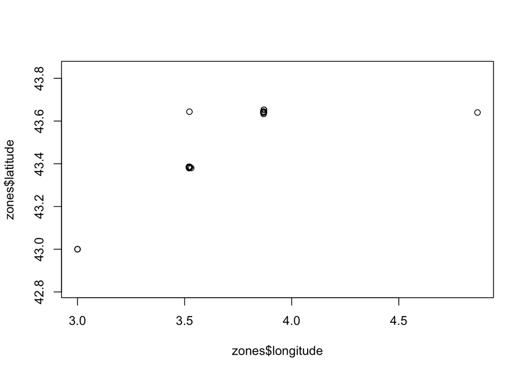

```r
# Force the aspect ratio
plot(x = zones$longitude, y = zones$latitude, asp = 1)
```

- With `attach()`: bad practice. See `?attach`.

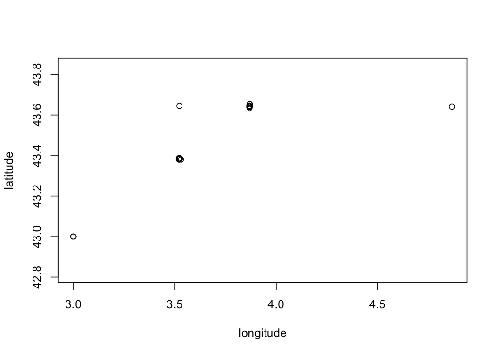

```r
attach(zones)
plot(x = longitude, y = latitude, asp = 1)
```

```r
# Don't forget to detach after use!
detach(zones)
```

- With `with()`.

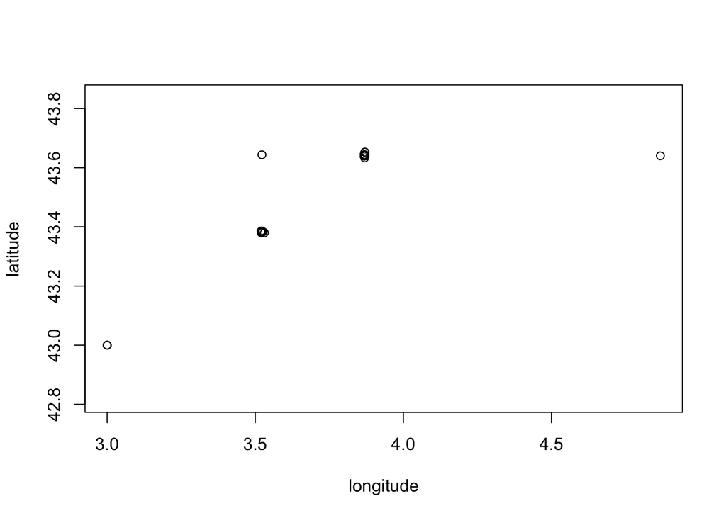

```r
with(zones,
  # Indent the code
  plot(x = longitude, y = latitude, asp = 1)
  # Close the bracket
)
```

## Tidyverse

### Build the community table

Complex data manipulation (data wrangling) is easier within the tidyverse.

Read the data.

```r
library("tidyverse")
zones <- read_csv2("data/zones2023.csv")
species <- read_csv2("data/especes2023.csv")
```

Make a pivot table.

```r
species %>%
  # Delete missing covers
  filter(!is.na(recouvrement)) %>%
  # Convert cover codes to numerical values
  mutate(
    cover_str = plyr::mapvalues(
      recouvrement,
      from = c("0", "i", "r", "+", "1", "2", "3", "4", "5"),
      to = c(0, .001, .005, .01, .025, .15, .375, .625, .875)
    )
  ) %>%
  # Make them really numerical
  mutate(cover = as.numeric(cover_str)) %>%
  # Gather genus and species
  mutate(species = paste(genre, espece, sep = "_")) %>%
  # Delete useless columns
  select(-genre, -espece, -recouvrement, -cover_str, -Observations) %>%
  # Pivot table
  pivot_wider(
    names_from = species,
    values_from = cover,
    values_fn = ~ sum(.x, na.rm = TRUE),
    values_fill = 0
  ) ->
  species_wide
zones %>%
  # Eliminate invalid rows
  filter(is.na(Invalide)) %>%
  # Eliminate extra columns
  select(Groupe:rec_espece_dominante_arboree) %>%
  # Join plots and species (inner join)
  inner_join(species_wide) ->
  montmaur
```

Make a pipeline to select rows and columns:

```r
montmaur %>%
  # Filter the north face
  filter(versant == "N") %>%
  # Select species columns
  select(!(Groupe:rec_espece_dominante_arboree)) %>%
  # Eliminate absent species
  select(where(~ sum(.x) != 0))
```

```
## # A tibble: 36 × 152
##    Arbutus_unedo Asparagus_acutifolius Brachypodium_retusum Clematis_sp
##            <dbl>                 <dbl>                <dbl>       <dbl>
##  1          0                    0                    0.15            0
##  2          0                    0                    0               0
##  3          0                    0                    0.375           0
##  4          0                    0                    0               0
##  5          0                    0                    0               0
##  6          0                    0                    0               0
##  7          0                    0.005                0               0
##  8          0.15                 0.005                0.01            0
##  9          0                    0.01                 0               0
## 10          0                    0.01                 0               0
## # ℹ 26 more rows
## # ℹ 148 more variables: Geranium_sp <dbl>, Pinus_halepensis <dbl>,
## #   Quercus_coccifera <dbl>, Quercus_ilex <dbl>, Quercus_pubescens <dbl>,
## #   Rhamnus_alaternus <dbl>, Rubia_peregrina <dbl>, Ruscus_aculeatus <dbl>,
## #   Smilax_aspera <dbl>, Taraxacum_officinale <dbl>, Viburnum_tinus <dbl>,
## #   Celtis_australis <dbl>, Clematis_flammula <dbl>, Hedera_helix <dbl>,
## #   Pistacia_terebinthus <dbl>, Carex_humilis <dbl>, …
```

Are some plots empty?

```r
# The first 10 columns contain plot data, the others, the species abundances
min(rowSums(montmaur[, -(1:10)]))
```

```
## [1] 0.134
```

Are some species missing?

```r
# The first 10 columns contain plot data, the others, the species abundances
which(colSums(montmaur[, -(1:10)]) == 0)
```

```
##       Hieracium_villosum    Lonicera_periclymenum       Polypodium_vulgare
##                        7                        8                       10
##    Taraxacum_officinalis             Allium_porum         Brachypodium_sp1
##                       27                       51                       52
##       Geranium_pussillum      Panaeolus_olivaceus            Rumex_pulcher
##                       54                       55                       57
## Selaginella_selaginoides    Soleirolia_soleirolii     Taraxacum_campylodes
##                       58                       59                       60
##       Trifolium_pratense        Veronica_agrestis   Bothriochloa_ischaemum
##                       61                       62                       64
##              Geranium_NA    Trifolium_suberraneum   Arenaria_serpyllifolia
##                       65                       66                       67
##         Cardamine_irusta    Panaeolus_antillarium  Psathyrella_candolleana
##                       68                       70                       72
##    Psilocybe_coprophilla
##                       73
```

```r
# Numbers are those of the columns. They are named.
```

Create a dataframe with species abundances only, and eliminate absent species

```r
montmaur_sp <- montmaur[, -(1:10)][, which(colSums(montmaur[, -(1:10)]) > 0)]
# Add the plot names
rownames(montmaur_sp) <- montmaur$code_releve
```

Make dataframes for the north and south face only:

```r
montmaur_sp_n <- montmaur_sp[montmaur$versant == "N", ]
montmaur_sp_s <- montmaur_sp[montmaur$versant == "S", ]
```

Graphical representation of the data table:

```r
library("ade4")
table.value(montmaur_sp_n, clegend = 0)
```

[output not shown]

Learn to make beautiful plots with **ggplot2** (Wickham et al. 2024) at the [R graph gallery](https://r-graph-gallery.com/).

# Rank-abundance diagram

Course: Marcon (2018), section [2.4](https://ericmarcon.github.io/MesuresBioDiv2/chap-Outils.html#distribution-de-labondance-des-esp%C3%A8ces-sad).

## Abundances: species cover

Compute the probability for an area to be covered by each species.

```r
# Sum the species cover
montmaur_cover <- colSums(montmaur_sp)
# Normalise
montmaur_cover <- montmaur_cover / sum(montmaur_cover)
```

Try to fit the distribution to a well-known one.

```r
library("vegan")
# Warnigs are due to non integer values.
radfit(montmaur_cover)
```

```
##
## RAD models, family poisson
## No. of species 187, total abundance 1
##
##            par1     par2    par3   Deviance AIC      BIC
## Null                               1.112633      Inf      Inf
## Preemption    0.1                  0.429862      Inf      Inf
## Lognormal  -7.1094   1.9929        0.058388      Inf      Inf
## Zipf        0.24005 -1.156         0.229926      Inf      Inf
## Mandelbrot  0.52091 -1.3694      1 0.149525      Inf      Inf
```

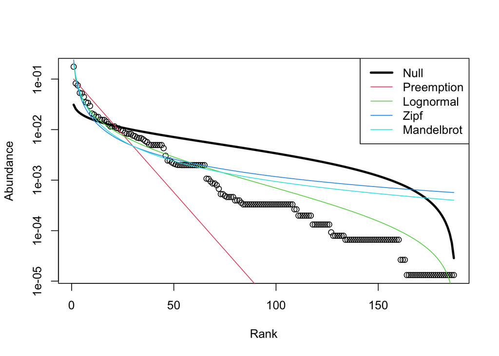

```r
plot(radfit(montmaur_cover))
```

## Occurrence

Count the number of plots where each species is observed.

```r
# Species occurrences
montmaur_occurrence <- specnumber(montmaur_sp, MARGIN = 2)
radfit(montmaur_occurrence)
```

```
##
## RAD models, family poisson
## No. of species 187, total abundance 737
##
##            par1      par2     par3   Deviance AIC     BIC
## Null                                 312.250  804.164 804.164
## Preemption  0.027037                 295.298  789.212 792.443
## Lognormal   0.53597   1.309          103.966  599.880 606.342
## Zipf        0.12819  -0.88243         65.984  561.898 568.360
## Mandelbrot  0.50733  -1.2134   3.418  21.725  519.639 529.332
```

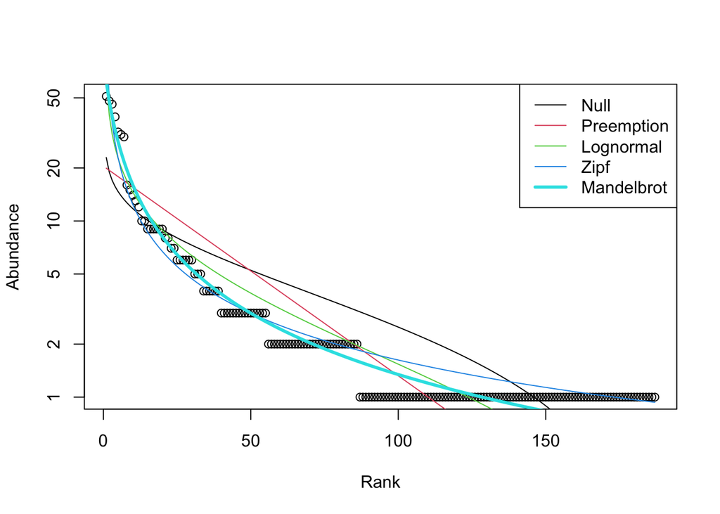

```r
plot(radfit(montmaur_occurrence))
```

## Compare abundance and occurence

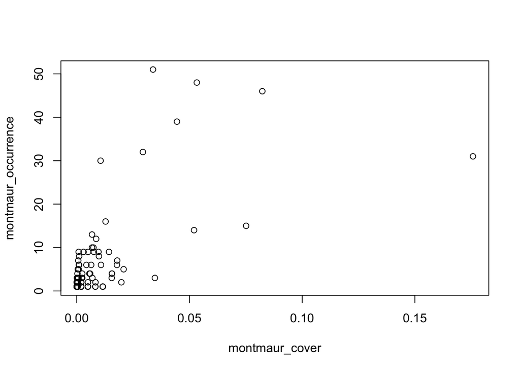

```r
plot(x = montmaur_cover, y = montmaur_occurrence)
```

# Taxonomic Diversity

Course: Marcon (2018), chapters [3](https://ericmarcon.github.io/MesuresBioDiv2/chap-MesuresNeutres.html) and [4](https://ericmarcon.github.io/MesuresBioDiv2/entropie.html).

## Richness

Count the number of species per plot.

```r
# Specific richness S
(plot_richness <- specnumber(montmaur_sp, MARGIN = 1))
```

```
##    AN4_1    AN4_2    AN4_3    AN5_1    AN5_2    AN5_3    AN6_1    AN6_2
##        4        3        5       10       14       11        7        9
##    AN6_3    AN7_1    AN7_2    AN7_3    AN8_1    AN8_2    AN8_3   AN11_1
##        8       16       15       17       10       11        8       15
##   AN11_2   AN11_3    AS1_1    AS1_2    AS1_3   AS12_1   AS12_2   AS12_3
##       12        8       12       15       16       14       12       11
##   AS99_1   AS99_2   AS99_3    BN1_1    BN1_2    BN1_3    BN7_1    BN7_2
##       12       12       13       15       16       16       12       12
##    BN7_3    BN8_1    BN8_2    BN8_3    BN9_1    BN9_2    BN9_3   BN11_1
##       15       13       14       19       11       11       10       20
##   BN11_2   BN11_3 BN7bis_1 BN7bis_2 BN7bis_3    BS4_1    BS4_2    BS4_3
##       18       16       11       15       13       14       10       12
##    BS6_1    BS6_2    BS6_3    BS7_1    BS7_2    BS7_3   BS10_1   BS10_2
##       11       15       12        8       10        8       12       11
##   BS10_3    AS8_1    AS8_2    AS8_3
##       12       14       10       21
```

## Accumulation curves

The level of diversity depends on the sampling effort.

### Assess diversity at a sampling level

Course: Marcon (2018), sections [2.1](https://ericmarcon.github.io/MesuresBioDiv2/chap-Outils.html#courbes-daccumulation) and 2.2.

Accumulation curves can be built by package **vegan** (Oksanen et al. 2022).

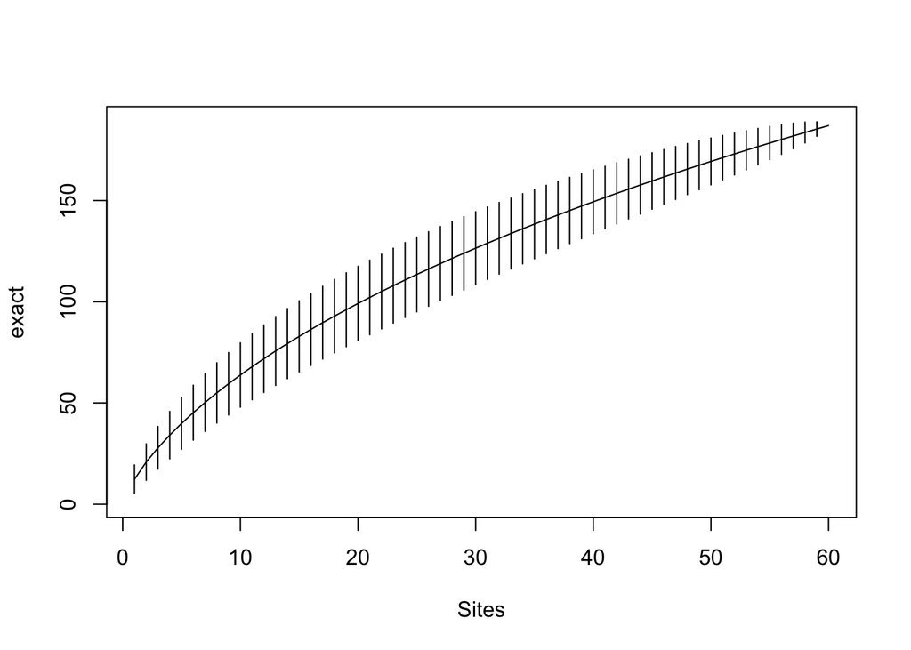

```r
library("vegan")
sac <- specaccum(montmaur_sp)
plot(sac)
```

```r
sac_n <- specaccum(montmaur_sp_n)
sac_s <- specaccum(montmaur_sp_s)
```

The number of species is in the `$richness` item of the `specaccum` object, which is a list.

```r
sac$richness
```

```
##  [1]  12.28333  20.79605  27.84544  34.11540  39.86286  45.21210  50.23659
##  [8]  54.98614  59.49774  63.80048  67.91813  71.87054  75.67454  79.34451
## [15]  82.89285  86.33031  89.66621  92.90870  96.06494  99.14122 102.14308
## [22] 105.07547 107.94275 110.74885 113.49728 116.19118 118.83340 121.42652
## [29] 123.97287 126.47459 128.93363 131.35178 133.73068 136.07186 138.37672
## [36] 140.64658 142.88265 145.08609 147.25796 149.39928 151.51099 153.59401
## [43] 155.64917 157.67731 159.67919 161.65556 163.60712 165.53456 167.43854
## [50] 169.31968 171.17859 173.01586 174.83206 176.62775 178.40345 180.15970
## [57] 181.89699 183.61582 185.31667 187.00000
```

```r
# Total richness is also
sum(colSums(montmaur_sp) != 0)
```

```
## [1] 187
```

Plot north and south SAC:

```r
plot(sac_n, ci.type = "line", ci.col = "blue")
plot(sac_s, ci.type = "line", ci.col = "red", add = TRUE)
```

[output not shown]

### Rarefaction to compare diversity

Course: Marcon (2018), chapter [21](https://ericmarcon.github.io/MesuresBioDiv2/chap-Accumulation.html#chap-Accumulation).

Rarefy the data to the smallest sample size.

```r
# Find the smallest number of plots
rarefied_n <- min(nrow(montmaur_sp_n), nrow(montmaur_sp_s))
# Estimate and estimator sd
# Ratified richness at n=rarefied_n plots
sac_n$richness[rarefied_n]
```

```
## [1] 120.4585
```

```r
sac_n$sd[rarefied_n]
```

```
## [1] 6.68894
```

```r
sac_s$richness[rarefied_n]
```

```
## [1] 84
```

```r
sac_s$sd[rarefied_n]
```

```
## [1] 0
```

Compare the diversity of north and south face.

## Extrapolation

Extrapolation is possible, up to twice the sample size without too much uncertainty. See the **iNext** package (Hsieh, Ma, and Chao 2016) for the [framework](https://cran.r-project.org/web/packages/iNEXT/vignettes/Introduction.pdf).

Extrapolation is easier with the **entropart** package.

```r
library("entropart")
Richness(montmaur_occurrence, Level = 2 * sum(montmaur_occurrence))
```

```
##    Best
## 250.819
```

Pot the accumulation curve:

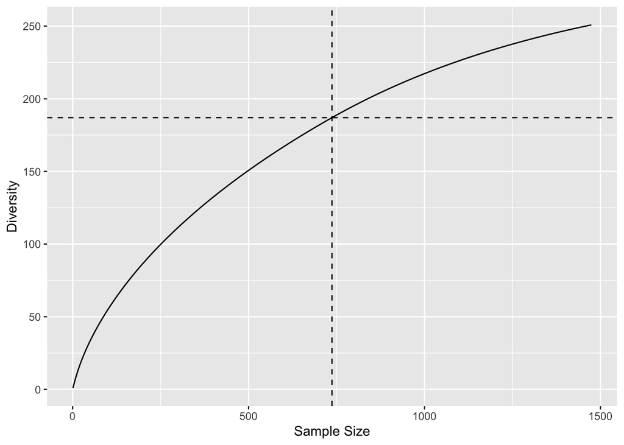

```r
autoplot(
  DivAC(
    montmaur_occurrence,
    q = 0,
    n.seq = 1:(2 * sum(montmaur_occurrence))
  )
)
```

## Asymptotic richness

Course: Marcon (2018), sections [2.2](https://ericmarcon.github.io/MesuresBioDiv2/chap-Outils.html#diversit%C3%A9-asymptotique) and [3.1](https://ericmarcon.github.io/MesuresBioDiv2/chap-MesuresNeutres.html#sec-Richesse)

Requires estimators based on the number of individuals or on the number of occurrences, available in package **entropart** (Marcon and Herault 2023).

```r
Richness(montmaur_occurrence, Correction = "Chao1")
```

```
##   Chao1
## 351.309
```

## Shannon, Simpson, entropy

Richness minus one species, Shannon (1948) and Simpson (1949) indices measure entropy, i.e. an amount of information.

In a community:

- The *probability* $p_s$ of a species is the probability for an individual to belong to it. When individuals are not well-defined, another definition must be chosen: with abundance-dominance data, it is the proportion of total coverage occupied by the species.
- The *rarity* of a species is the reciprocal of its probability, i.e. $1/p_s$.
- The information brought by the species is:
  - $(1-p_s)/p_s$ for richness (full line)
  - the logarithm of rarity for Shannon ($\ln(1/p_s)$) (long dashes),
  - $1-p_s$ for Simpson (sort dashes).

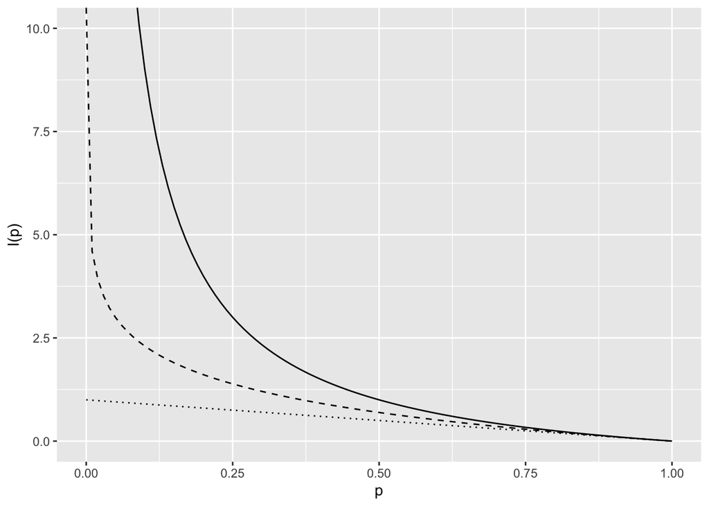

```r
I0 <- function(p) (1 - p) / p
I1 <- function(p) -log(p)
I2 <- function(p) 1 - p
ggplot(data.frame(x=c(0, 1)), aes(x)) +
    stat_function(fun = I0) +
    stat_function(fun = I1, lty = 2) +
    stat_function(fun = I2, lty = 3) +
    coord_cartesian(ylim = c(0, 10)) +
    labs(x = "p", y = "I(p)")
```

- The entropy of the community is the average information brought by its species.

The information function gives more (richness) or less (Simpson) weight to rare species.

```r
# Shannon
Shannon(montmaur_occurrence, Correction = "None")
```

```
##     None
## 4.360169
```

```r
# Asymptotic
Shannon(montmaur_occurrence)
```

```
##  UnveilJ
## 4.701297
```

```r
# Cover data
Shannon(montmaur_cover)
```

```
##     None
## 3.540317
```

Simpson’s entropy is the probability for two individuals to belong to different species.

```r
# Simpson
Simpson(montmaur_occurrence, Correction = "None")
```

```
##      None
## 0.9740688
```

```r
# Asymptotic
Simpson(montmaur_occurrence)
```

```
##     Lande
## 0.9753923
```

```r
# Cover data
Simpson(montmaur_cover)
```

```
##      None
## 0.9416434
```

The generalized entropy extends this approach. The deformed logarithm function of order $q$ is $\ln_q(x) = \frac{x^{1-q} - 1}{1 - q}$.

- the natural logarithm for $q=1$ : $\ln_1(x) = \ln(x)$.
- a more concave function for $q > 1$ : $\ln_2(x) = 1 - 1/x$.
- a less concave function for $q < 1$ : $\ln_0(x) = x - 1$.

## Diversity

Diversity sensu stricto is the number of equiprobable species that would yield the same entropy as the data. It is called a Hill (1973) number or a number equivalent or the effective number of species (Jost 2006).

It is the exponential of Shannon’s entropy and the reciprocal of Simpson’s similarity.

```r
# Shannon
Diversity(montmaur_cover, q = 1)
```

```
##     None
## 34.47784
```

```r
exp(Shannon(montmaur_cover))
```

```
##     None
## 34.47784
```

```r
# Simpson
Diversity(montmaur_cover, q = 2)
```

```
##     None
## 17.13602
```

```r
1 / (1 - Simpson(montmaur_cover))
```

```
##     None
## 17.13602
```

In general, diversity of order $q$ is the deformed exponential of entropy of order $q$.

```r
# Simpson
expq(Simpson(montmaur_cover), q = 2)
```

```
##     None
## 17.13602
```

```r
# From diversity to entropy
lnq(Diversity(montmaur_cover, q = 2), q = 2)
```

```
##      None
## 0.9416434
```

## Diversity profile

Plot diversity with respect to its order.

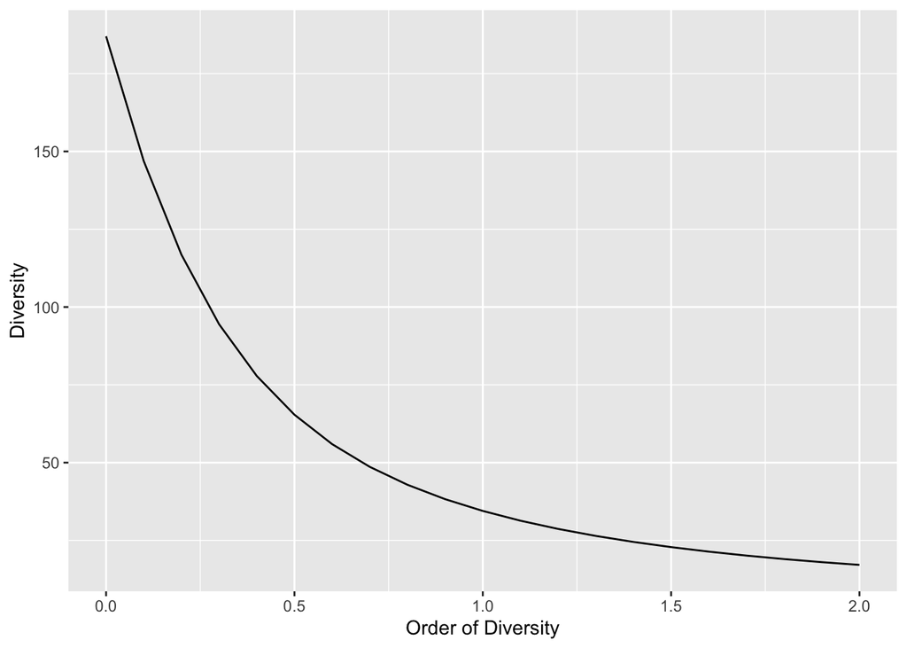

```r
autoplot(CommunityProfile(Diversity, montmaur_cover))
```

# Functional diversity

```r
# Read the data
"data/traits2023.csv" %>%
  read_csv2() %>%
  # Eliminate missing data
  filter(!is.na(type_biologique)) %>%
  filter(!is.na(chlorophylle)) %>%
  # Create the species name column
  mutate(code_espece = paste(genre, espece, sep = "_")) ->
  traits
# chlorophyll
trait_chlorophyll <- aggregate(chlorophylle ~ code_espece, data = traits, FUN = mean)
# Biological type
trait_type <- aggregate(type_biologique ~ code_espece, data = traits, FUN = unique)
# Trait table
traits <- cbind(trait_chlorophyll, trait_type)
# Delete doubled column and keep observed species only
traits <- traits[traits$code_espece %in% colnames(montmaur_sp), -3]
head(traits)
```

```
##          code_espece chlorophylle type_biologique
## 3 Calendula_arvensis        26.86    Phanérophyte
## 4     Cistus_albidus        32.24      Chaméphyte
## 5  Clematis_armandii        37.04      Chaméphyte
## 6  Clematis_flammula        47.44      Chaméphyte
## 7       Hedera_helix        53.84    Phanérophyte
## 8   Lonicera_implexa        51.70      Chaméphyte
```

## Community weighted mean

Course: Marcon (2018), section [7.7](https://ericmarcon.github.io/MesuresBioDiv2/mesures-particuli%C3%A8res.html#diversit%C3%A9-et-moyenne).

Defined by Garnier et al. (2004). CWM is a mean, not a diversity.

```r
species_weights <- colSums(montmaur_sp)[colnames(montmaur_sp) %in% traits$code_espece]
mean(traits$chlorophylle, w = species_weights)
```

```
## [1] 44.19231
```

```r
# By type (unweighted). Does not work if type_biologique is not consistent
aggregate(chlorophylle ~ type_biologique, data = traits, FUN = mean)
```

```
##   type_biologique chlorophylle
## 1      Chaméphyte     46.29800
## 2 Hémicryptophyte     32.84667
## 3    Phanérophyte     47.27153
## 4      Thérophyte     42.09000
```

For intensive use, see `BAT::cwm()`.

## Functional Distance

Course: Marcon (2018), chapter [6](https://ericmarcon.github.io/MesuresBioDiv2/chap-cadrephyfonc.html#chap-cadrephyfonc).

Functional distance between species following Gower (1971).

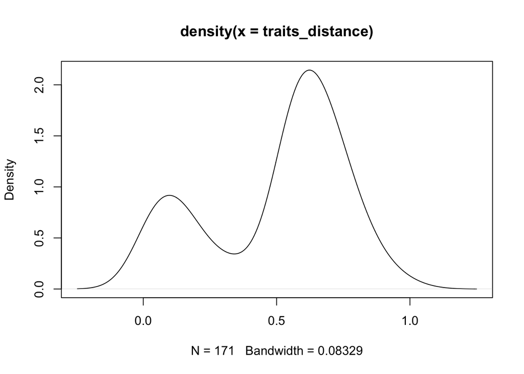

```r
library("FD")
# Distances based on traits, not including species names.
# type_biologique must be consistent (or it is a list)
traits_distance <- gowdis(traits[, -1])
plot(density(traits_distance))
```

## Quadratic entropy

Course: Marcon (2018), section [7.6](https://ericmarcon.github.io/MesuresBioDiv2/mesures-particuli%C3%A8res.html#sec-Rao).

Rao’s entropy (aka quadratic entropy) is the average distance between two individuals.

```r
library("adiv")
montmaur_qe <- QE(
  comm = montmaur_sp[, traits$code_espece],
  dis = traits_distance
)
```

## Hierarchical classification

Functional classification of species (complementarity-redundancy) with CAH (mean linkage) based on Gower distances:

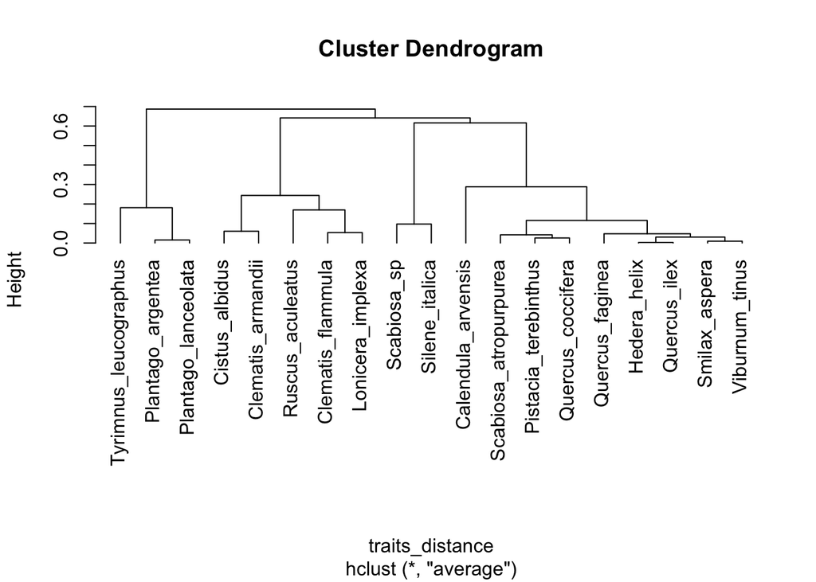

```r
# Restore the species names
attr(traits_distance, "Labels") <- traits$code_espece
species_fhc <- hclust(traits_distance, method = "average")
plot(species_fhc, hang = -1)
```

# Phylogenetic diversity

Course: Marcon (2018), chapter [8](https://ericmarcon.github.io/MesuresBioDiv2/chap-Phyloentropie.html#chap-Phyloentropie).

Defined to assess the dissimilarities between species summarized in a dendrogram. We’ll use the functional dendrogram above as an exercice, even though it is not a good approach to measure functional diversity.

The dendrogram is cut into slices at each node height. Entropy is calculated in each slice and averaged along the tree: it is the average information along time (if the dendrogram represents evolutionary times) and diversity is its exponential.

PD (Faith 1992), aka FD (Petchey and Gaston 2006) is the total length of branches, i.e. richness.

```r
# Subset the data: keep species of the tree only
montmaur_reduced <- montmaur_occurrence[
  names(montmaur_occurrence) %in% species_fhc$labels
]
# FD
PDFD(as.ProbaVector(montmaur_reduced), species_fhc)
```

```
##     None
## 3.325656
```

Entropy of order 2 is the average distance between two individuals, i.e. Rao’s entropy.

```r
# Asymptotic Rao's entropy in a normalized tree
PhyloEntropy(montmaur_reduced, q = 2, Tree = species_fhc, Normalize = TRUE)
```

```
## $Distribution
## [1] "-"
##
## $Function
## [1] "PhyloEntropy"
##
## $Tree
## [1] "species_fhc"
##
## $Normalized
## [1] TRUE
##
## $Cuts
## 0.00272450259903212  0.0093385911453665  0.0155583437892094  0.0258051024675867
##          0.88141869          0.87446176          0.81138269          0.81105379
##  0.0302294317978132  0.0418025930572982  0.0473427137479834  0.0534504391468006
##          0.80291300          0.69745723          0.69506821          0.69089062
##  0.0602258469259723  0.0971141781681304   0.115715679831113   0.169385194479297
##          0.68861219          0.68845867          0.68543388          0.52008724
##   0.181179422835633   0.243789209535759   0.288117643544243   0.615875007468483
##          0.49994261          0.49925390          0.49107553          0.48599633
##   0.641317711982706   0.686684815080361
##          0.41448577          0.07288797
##
## $Corrections
## 0.00272450259903212  0.0093385911453665  0.0155583437892094  0.0258051024675867
##           "UnveilJ"           "UnveilJ"           "UnveilJ"           "UnveilJ"
##  0.0302294317978132  0.0418025930572982  0.0473427137479834  0.0534504391468006
##           "UnveilJ"           "UnveilJ"           "UnveilJ"           "UnveilJ"
##  0.0602258469259723  0.0971141781681304   0.115715679831113   0.169385194479297
##           "UnveilJ"           "UnveilJ"           "UnveilJ"           "UnveilJ"
##   0.181179422835633   0.243789209535759   0.288117643544243   0.615875007468483
##           "UnveilJ"           "UnveilJ"           "UnveilJ"           "UnveilJ"
##   0.641317711982706   0.686684815080361
##           "UnveilJ"           "UnveilJ"
##
## $Total
## [1] 0.5009958
##
## $Type
## [1] "alpha or gamma"
##
## $Order
## [1] 2
##
## $Correction
## [1] "Best"
##
## attr(,"class")
## [1] "PhyloEntropy" "PhyloValue"
```

Diversity is its deformed exponential of order 2, i.e. 1/(1 - entropy).

```r
PhyloDiversity(montmaur_reduced, q = 2, Tree = species_fhc, Normalize = TRUE)$Total
```

```
## [1] 2.003991
```

# Beta diversity

Course: Marcon (2018), chapter [10](https://ericmarcon.github.io/MesuresBioDiv2/sec-betaCadre.html).

## Partitioning

Course: Marcon (2018), chapter [12](https://ericmarcon.github.io/MesuresBioDiv2/chap-DedompHCDT.html#chap-DedompHCDT).

Défined by Whittaker (1960). Multiplicative partitioning:

```r
# Total number of species
richness_gamma <- sum(colSums(montmaur_sp) > 0)
# Average number of species per plot
richness_plot <- apply(montmaur_sp, MARGIN = 1, FUN = function(plot) sum(plot > 0))
richness_alpha <- mean(richness_plot)
richness_beta <- richness_gamma / richness_alpha
```

$\beta$ diversity is the effective number of plots, i.e. the number of equally-weighted plots that would yield the same diversity as the data.

Additive partitioning (Lande 1996):

```r
richness_gamma - richness_alpha
```

```
## [1] 174.7167
```

Additive partitioning is valid for entropy.

## Differentiation

Course: Marcon (2018), chapter [11](https://ericmarcon.github.io/MesuresBioDiv2/chap-BetaPaires.html#chap-BetaPaires).

How different are two plots?

Jaccard dissimilarity is based on occurrence data.

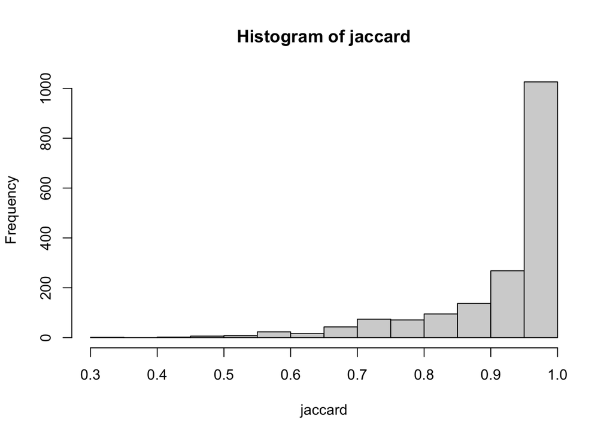

```r
library("vegan")
jaccard <-vegdist(montmaur_sp, method = "jaccard")
hist(jaccard)
```

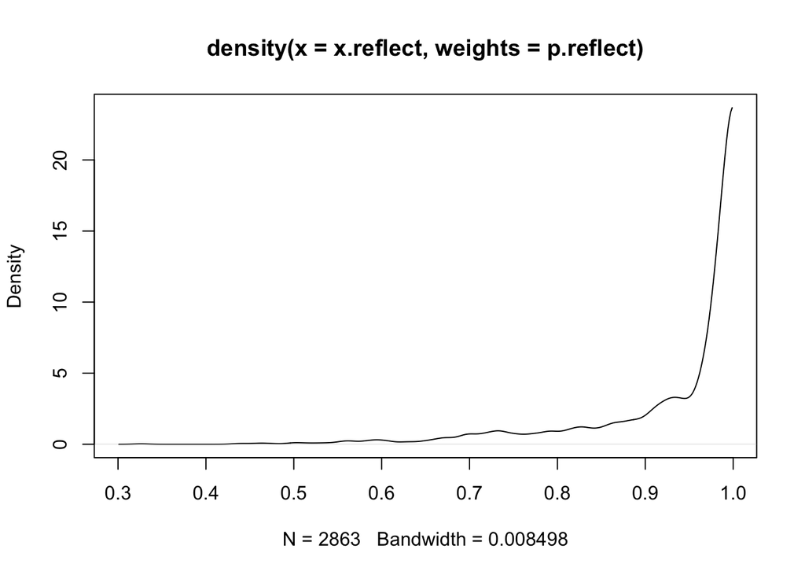

```r
# Smooth the histogram, no values above 1
library("GoFKernel")
plot(density.reflected(jaccard, upper = 1))
```

Bray-Curtis dissimilarity is based on abundance data.

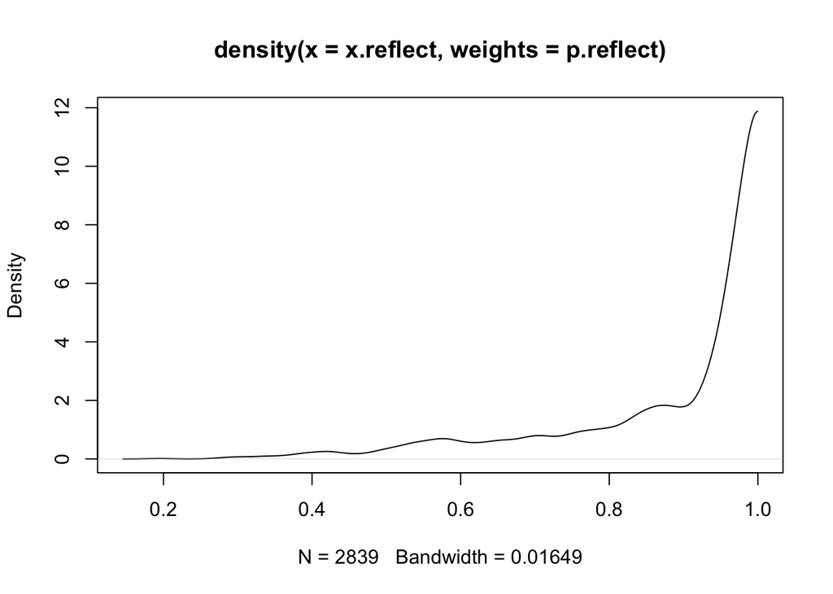

```r
bray <-vegdist(montmaur_sp, method = "bray")
plot(density.reflected(bray, upper = 1))
```

## Conciliation

The figure of plots after a non-scaled, centred PCA shows the contribution of each plot to Simpson’s $\beta$ entropy (partitioning). The distance between plots is Simpson’s $\beta$ entropy between them (differentiation).

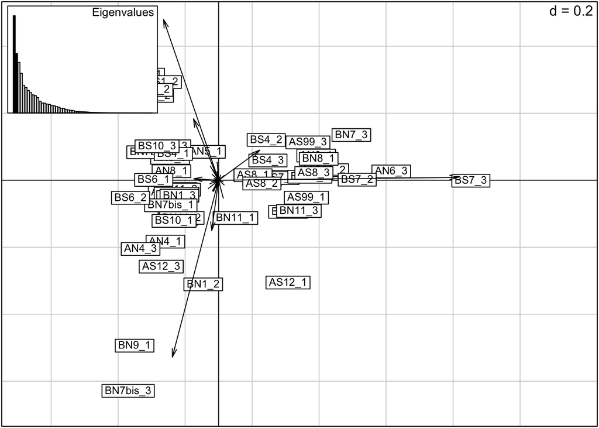

```r
montmaur_pca <- dudi.pca(
  montmaur_sp/rowSums(montmaur_sp),
  scannf = FALSE,
  nf = 2,
  center = TRUE,
  scale = FALSE
)
scatter(montmaur_pca, clab.col = 0)
```

# References

Faith, Daniel P. 1992. “Conservation Evaluation and Phylogenetic Diversity.” *Biological Conservation* 61 (1): 1–10. https://doi.org/10.1016/0006-3207(92)91201-3.

Garnier, Eric, Jacques Cortez, Georges Billès, Marie-Laure Navas, Catherine Roumet, Max Debussche, Gérard Laurent, et al. 2004. “Plant Functional Markers Capture Ecosystem Properties During Secondary Succession.” *Ecology* 85 (9): 2630–37. https://doi.org/10.1890/03-0799.

Gower, J. C. 1971. “A General Coefficient of Similarity and Some of Its Properties.” *Biometrics* 27 (4): 857–71. https://doi.org/10.2307/2528823.

Hill, M. O. 1973. “Diversity and Evenness: A Unifying Notation and Its Consequences.” *Ecology* 54 (2): 427–32. https://doi.org/10.2307/1934352.

Hsieh, T. C., K. H. Ma, and Anne Chao. 2016. “iNEXT: An R Package for Interpolation and Extrapolation in Measuring Species Diversity.” *Methods in Ecology and Evolution* 7: 1451–56. https://doi.org/10.1111/2041-210X.12613.

Jost, Lou. 2006. “Entropy and Diversity.” *Oikos* 113 (2): 363–75. https://doi.org/10.1111/j.2006.0030-1299.14714.x.

Lande, Russell. 1996. “Statistics and Partitioning of Species Diversity, and Similarity Among Multiple Communities.” *Oikos* 76 (1): 5–13. https://doi.org/10.2307/3545743.

Marcon, Eric. 2018. *Mesures de La Biodiversité*. Kourou, France: UMR EcoFoG.

Marcon, Eric, and Bruno Herault. 2023. *Entropart: Entropy Partitioning to Measure Diversity*. https://github.com/EricMarcon/entropart.

Oksanen, Jari, Gavin L. Simpson, F. Guillaume Blanchet, Roeland Kindt, Pierre Legendre, Peter R. Minchin, R. B. O’Hara, et al. 2022. *Vegan: Community Ecology Package*. https://github.com/vegandevs/vegan.

Petchey, Owen L., and Kevin J. Gaston. 2006. “Functional Diversity: Back to Basics and Looking Forward.” *Ecology Letters* 9 (6): 741–58. https://doi.org/10.1111/j.1461-0248.2006.00924.x.

Shannon, Claude E. 1948. “A Mathematical Theory of Communication.” *The Bell System Technical Journal* 27 (3): 379–423, 623–56. https://doi.org/10.1002/j.1538-7305.1948.tb01338.x.

Simpson, E. H. 1949. “Measurement of Diversity.” *Nature* 163 (4148): 688. https://doi.org/10.1038/163688a0.

Whittaker, R. H. 1960. “Vegetation of the Siskiyou Mountains, Oregon and California.” *Ecological Monographs* 30 (3): 279–338. https://doi.org/10.2307/1943563.

Wickham, Hadley, Winston Chang, Lionel Henry, Thomas Lin Pedersen, Kohske Takahashi, Claus Wilke, Kara Woo, Hiroaki Yutani, Dewey Dunnington, and Teun van den Brand. 2024. *Ggplot2: Create Elegant Data Visualisations Using the Grammar of Graphics*. https://ggplot2.tidyverse.org.